# Olympic Archery

Christopher Arzate Benitez

3/16/2022

The art of Archery: Using a bow and arrow to see how accurate one can hit their target. This art will be shown well especially in the most important sports event in the world, the Olympics. In this project, I’ll be discussing how countries did well in archery by using medal numbers. Then we see specific countries and how each sex earned their medals for their team. But first, we must discuss the history of archery in the Olympics.

Olympics was the introduced in the second ever Olympics in 1900[^1] however it wasn’t a recurring event the Olympics till 1972. We can see that in the table if we filter the sorts to be archery and see the unique values for year.

```r
unique(Archery[("Year")])
```

```
##      Year
## 1    1900
## 33   1904
## 103  1908
## 180  1920
## 266  1972
## 361  1976
## 425  1980
## 492  1984
## 601  1988
## 858  1992
## 1105 1996
## 1323 2000
## 1529 2004
## 1741 2008
## 1935 2012
## 2135 2016
```

```r
Archery$Medal<-as.factor(Archery$Medal)
Archery$Medal<-fct_relevel(Archery$Medal,c("Gold","Silver","Bronze"))
```

In the years, 1900, 1904, 1908, and 1920 were the early stages of archery. The events during these times weren’t organized and the rules were inconsistent between these four events. This made the people in charge of the Olympics to remove archery. Luckily, a committee was created in 1931 to add archery back to the Olympics and they did in 1972. After the reintroduction, the sport became reoccurring sport in Olympics[^2].

This will just affect the amount of medals given if we compare them to different sports but comparing isn’t the main focus.

## General Archery information

In the last 16 Olympic events, a total of 1,113 participants have participated for Archery

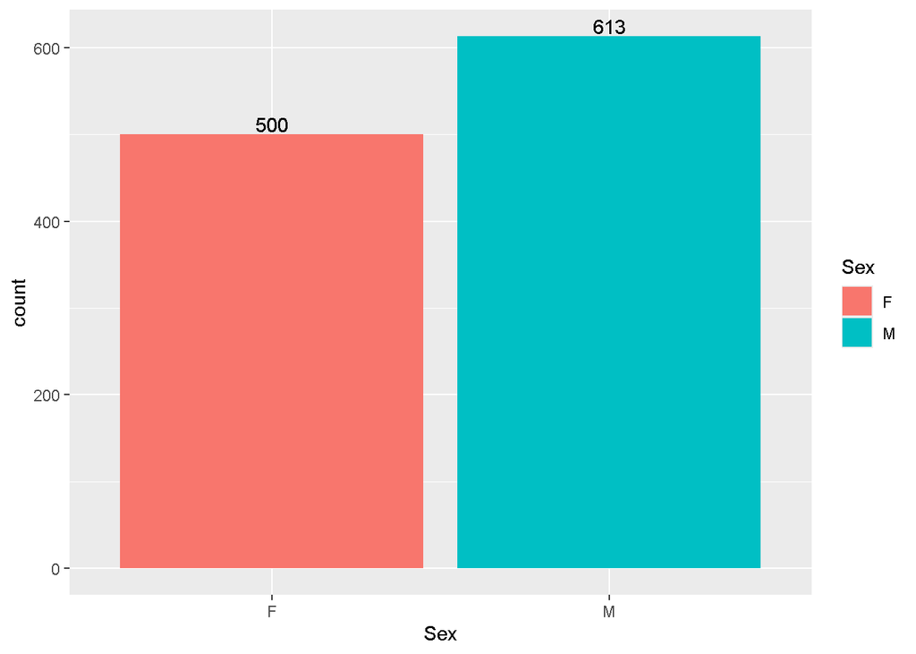

```r
A_sex<-Archery%>%
  group_by(Name, Sex) %>%
  summarise(count=n())

ggplot(A_sex,aes(x=Sex,fill=Sex))+
  geom_bar()+
  geom_text(aes(label = ..count..),stat="count",vjust = -0.2)
```

Of those participants, about 500 of them are females and 613 are males. Now let’s inspect the amount of countries participated in archery.

```r
countries<-Archery %>%
  group_by(Team) %>%
  summarise(participants=n()) %>%
  filter(participants>25) %>%
  arrange(-participants)
```

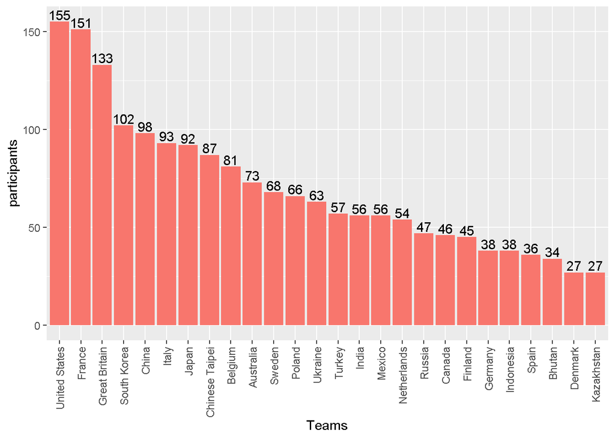

```r
ggplot(countries,aes(x=fct_reorder(Team,-participants),y=participants,fill="red"))+
  geom_col(show.legend = FALSE)+
  theme(axis.text.x = element_text(angle = 90, vjust = 0.5, hjust=1))+
  geom_text(aes(label = participants), vjust = -0.2)+
  labs(x="Teams",Y="Participants", Title="Participants")
```

With those participants, the United States, France, Great Britain, South Korea and China are the top countries to send people for archery. And about 102 countries have sent archery participants and the top five countries to participate in Archery were the United States, France,Great Britain, South Korea, and China.

Those that mean the more participated must have the most medals? Answer is no and we will see that countries like Belgium who aren’t in the top five is one of the best in archery.